# Question 1: Exercise 2.13

The nurse manager of an intensive care unit would like to develop a budget for medical supplies that is based on patient days provided in Table EX 2.13.

```python
# Import dataset
import pandas as pd
q1 = pd.read_excel('IE5400_HW02_Q1-6.xlsx')
```

### a. Using a linear regression model, develop predictions for costs in periods 1 through 18 based on patient days.

```python
# Libraries
%matplotlib inline
import numpy as np
import matplotlib.pyplot as plt
from scipy import stats
```

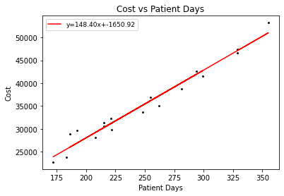

```python
# variables
x = q1['Patient Days']
y = q1['Cost']

# Regression
slope, intercept, r_value, p_value, std_err = stats.linregress(x,y)

# Plot points with regression line
line = slope*x+intercept
plt.plot(x, line, 'r', label='y={:.2f}x+{:.2f}'.format(slope,intercept))

plt.scatter(x,y, color="k", s=3.5)
plt.legend(fontsize=9)
plt.xlabel("Patient Days")
plt.ylabel("Cost")
plt.title("Cost vs Patient Days")
plt.show()
```

```python
# Insert prediction costs using the equation
q1['Prediction'] = (slope * q1['Patient Days']) + intercept

# Get error (forecast - demand)
q1['Error'] = q1['Prediction'] - q1['Cost']

# Show data frame
q1
```

|  | Period | Patient Days | Cost | Prediction | Error |
| --- | --- | --- | --- | --- | --- |
| 0 | 1 | 329 | 46718 | 47172.103327 | 454.103327 |
| 1 | 2 | 355 | 53250 | 51030.457968 | -2219.542032 |
| 2 | 3 | 329 | 47376 | 47172.103327 | -203.896673 |
| 3 | 4 | 215 | 31390 | 30254.702209 | -1135.297791 |
| 4 | 5 | 299 | 41561 | 42720.155665 | 1159.155665 |
| 5 | 6 | 262 | 35108 | 37229.420214 | 2121.420214 |
| 6 | 7 | 248 | 33728 | 35151.844638 | 1423.844638 |
| 7 | 8 | 186 | 28830 | 25951.152802 | -2878.847198 |
| 8 | 9 | 192 | 29568 | 26841.542335 | -2726.457665 |
| 9 | 10 | 221 | 32266 | 31145.091742 | -1120.908258 |
| 10 | 11 | 281 | 38778 | 40048.987067 | 1270.987067 |
| 11 | 12 | 294 | 42630 | 41978.164388 | -651.835612 |
| 12 | 13 | 255 | 36975 | 36190.632426 | -784.367574 |
| 13 | 14 | 215 | 30530 | 30254.702209 | -275.297791 |
| 14 | 15 | 208 | 28080 | 29215.914421 | 1135.914421 |
| 15 | 16 | 222 | 29748 | 31293.489997 | 1545.489997 |
| 16 | 17 | 183 | 23790 | 25505.958036 | 1715.958036 |
| 17 | 18 | 172 | 22704 | 23873.577226 | 1169.577226 |

### b. What is the prediction error in period 1? What is the prediction error in period 18?

```python
# Period 1
print("$", "%.2f" % round(q1['Error'].loc[q1.Period == 1].mean(), 2), sep = '')
```

```
$454.10
```

```python
# Period 18
print("$", round(q1['Error'].loc[q1.Period == 18].mean(), 2), sep = '')
```

```
$1169.58
```

### c. Predict costs when patient days are 200, 300, and 400.

```python
for i in range(200, 500, 100):
    print(i, " Days: $", round(slope * i + intercept, 2), sep = '')
```

```
200 Days: $28028.73
300 Days: $42868.55
400 Days: $57708.38
```

# Question 2: Exercise 2.19

The average daily visits to an urgent care clinic per month are shown in Table EX 2.19.

### a. Develop a linear regression prediction model based on the average visits in each month.

```python
# Import Excel file
q2 = pd.read_excel('IE5400_HW02_Q1-6.xlsx', sheet_name = '2.19')

# Add average columns, take mean by rows
q2['Monthly Average'] = q2.mean(axis=1)
```

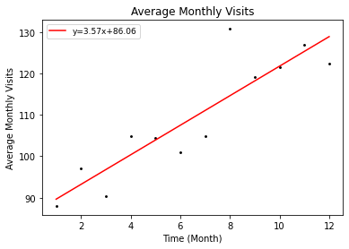

```python
# Variables
x = np.array(range(1, 13))
y = q2['Monthly Average']

# Regression
slope, intercept, r_value, p_value, std_err = stats.linregress(x,y)
line = (slope * x) + intercept
plt.plot(x, line, 'r', label='y={:.2f}x+{:.2f}'.format(slope,intercept))

plt.scatter(x, y, color = "k", s = 3.5)
plt.legend(fontsize = 9)
plt.xlabel("Time (Month)")
plt.ylabel("Average Monthly Visits")
plt.title("Average Monthly Visits")
plt.show()
```

```python
# Show data frame
q2
```

|  | Month | Monday | Tuesday | Wednesday | Thursday | Friday | Monthly Average |
| --- | --- | --- | --- | --- | --- | --- | --- |
| 0 | January | 77 | 99 | 78 | 88 | 98 | 88.0 |
| 1 | February | 85 | 92 | 113 | 102 | 93 | 97.0 |
| 2 | March | 72 | 76 | 91 | 113 | 100 | 90.4 |
| 3 | April | 115 | 115 | 88 | 99 | 107 | 104.8 |
| 4 | May | 89 | 109 | 114 | 112 | 98 | 104.4 |
| 5 | June | 79 | 85 | 110 | 118 | 113 | 101.0 |
| 6 | July | 92 | 111 | 99 | 108 | 114 | 104.8 |
| 7 | August | 105 | 122 | 152 | 140 | 135 | 130.8 |
| 8 | September | 98 | 105 | 119 | 136 | 138 | 119.2 |
| 9 | October | 123 | 120 | 138 | 111 | 116 | 121.6 |
| 10 | November | 91 | 137 | 140 | 139 | 128 | 127.0 |
| 11 | December | 115 | 109 | 110 | 144 | 134 | 122.4 |

### b. Predict the visits for January through March of the following year.

```python
# new column of all predictions
q2['Monthly Predictions'] = slope * range(1, 13) + intercept
```

```python
# January, February, March
for i in range(1, 4):
    print("Month ", i, ": ", round(slope * i + intercept), " Visits", sep = '')
```

```
Month 1: 90.0 Visits
Month 2: 93.0 Visits
Month 3: 97.0 Visits
```

### c. Develop daily and monthly indexes for urgent care clinic visits.

#### Daily Index

```python
# Transpose data, drop last two rows
q2_transpose = q2.rename(columns = {'Month':'Day/Month'})
q2_transpose = q2_transpose.transpose()
q2_transpose.drop(q2_transpose.tail(3).index, inplace = True)

# Change column names
new_header = q2_transpose.iloc[0]
q2_transpose = q2_transpose[1:]
q2_transpose.columns = new_header

# Get daily average and daily index
q2_transpose['Daily Average'] = q2_transpose.mean(axis=1)
q2_transpose['Daily Index'] = q2_transpose['Daily Average'] / q2_transpose['Daily Average'].mean()

q2_transpose
```

| Day/Month | January | February | March | April | May | June | July | August | September | October | November | December | Daily Average | Daily Index |
| --- | --- | --- | --- | --- | --- | --- | --- | --- | --- | --- | --- | --- | --- | --- |
| Monday | 77 | 85 | 72 | 115 | 89 | 79 | 92 | 105 | 98 | 123 | 91 | 115 | 95.083333 | 0.880571 |
| Tuesday | 99 | 92 | 76 | 115 | 109 | 85 | 111 | 122 | 105 | 120 | 137 | 109 | 106.666667 | 0.987845 |
| Wednesday | 78 | 113 | 91 | 88 | 114 | 110 | 99 | 152 | 119 | 138 | 140 | 110 | 112.666667 | 1.043411 |
| Thursday | 88 | 102 | 113 | 99 | 112 | 118 | 108 | 140 | 136 | 111 | 139 | 144 | 117.500000 | 1.088173 |

#### Monthly Index

```python
q2['Monthly Index'] = q2['Monthly Average'] / q2['Monthly Average'].mean()
q2
```

|  | Month | Monday | Tuesday | Wednesday | Thursday | Friday | Monthly Average | Monthly Predictions | Monthly Index |
| --- | --- | --- | --- | --- | --- | --- | --- | --- | --- |
| 0 | January | 77 | 99 | 78 | 88 | 98 | 88.0 | 89.633333 | 0.805246 |
| 1 | February | 85 | 92 | 113 | 102 | 93 | 97.0 | 93.206061 | 0.887601 |
| 2 | March | 72 | 76 | 91 | 113 | 100 | 90.4 | 96.778788 | 0.827208 |
| 3 | April | 115 | 115 | 88 | 99 | 107 | 104.8 | 100.351515 | 0.958975 |
| 4 | May | 89 | 109 | 114 | 112 | 98 | 104.4 | 103.924242 | 0.955315 |
| 5 | June | 79 | 85 | 110 | 118 | 113 | 101.0 | 107.496970 | 0.924203 |
| 6 | July | 92 | 111 | 99 | 108 | 114 | 104.8 | 111.069697 | 0.958975 |
| 7 | August | 105 | 122 | 152 | 140 | 135 | 130.8 | 114.642424 | 1.196889 |
| 8 | September | 98 | 105 | 119 | 136 | 138 | 119.2 | 118.215152 | 1.090743 |
| 9 | October | 123 | 120 | 138 | 111 | 116 | 121.6 | 121.787879 | 1.112704 |
| 10 | November | 91 | 137 | 140 | 139 | 128 | 127.0 | 125.360606 | 1.162117 |
| 11 | December | 115 | 109 | 110 | 144 | 134 | 122.4 | 128.933333 | 1.120024 |

### d. Use the monthly indexes technique to develop the monthly adjusted predictions for January through March.

```python
# Multiply forecast by the seasonality factor
q2['Monthly Adjusted Predictions'] = q2['Monthly Predictions'] * q2['Monthly Index']
q2
```

|  | Month | Monday | Tuesday | Wednesday | Thursday | Friday | Monthly Average | Monthly Predictions | Monthly Index | Monthly Adjusted Predictions |
| --- | --- | --- | --- | --- | --- | --- | --- | --- | --- | --- |
| 0 | January | 77 | 99 | 78 | 88 | 98 | 88.0 | 89.633333 | 0.805246 | 72.176910 |
| 1 | February | 85 | 92 | 113 | 102 | 93 | 97.0 | 93.206061 | 0.887601 | 82.729796 |
| 2 | March | 72 | 76 | 91 | 113 | 100 | 90.4 | 96.778788 | 0.827208 | 80.056145 |
| 3 | April | 115 | 115 | 88 | 99 | 107 | 104.8 | 100.351515 | 0.958975 | 96.234608 |
| 4 | May | 89 | 109 | 114 | 112 | 98 | 104.4 | 103.924242 | 0.955315 | 99.280380 |
| 5 | June | 79 | 85 | 110 | 118 | 113 | 101.0 | 107.496970 | 0.924203 | 99.349037 |
| 6 | July | 92 | 111 | 99 | 108 | 114 | 104.8 | 111.069697 | 0.958975 | 106.513078 |
| 7 | August | 105 | 122 | 152 | 140 | 135 | 130.8 | 114.642424 | 1.196889 | 137.214236 |
| 8 | September | 98 | 105 | 119 | 136 | 138 | 119.2 | 118.215152 | 1.090743 | 128.942316 |
| 9 | October | 123 | 120 | 138 | 111 | 116 | 121.6 | 121.787879 | 1.112704 | 135.513858 |
| 10 | November | 91 | 137 | 140 | 139 | 128 | 127.0 | 125.360606 | 1.162117 | 145.683669 |
| 11 | December | 115 | 109 | 110 | 144 | 134 | 122.4 | 128.933333 | 1.120024 | 144.408479 |

# Question 3: Exercise 2.26

```python
# Import dataset
q3 = pd.read_excel('IE5400_HW02_Q1-6.xlsx', sheet_name = '2.26')

# Moving Average
q3['Moving Average (5P)'] = [None] * len(q3)

import warnings
warnings.filterwarnings("ignore")

for i in range(5, len(q3)):
    prev_5 = q3['Enrollment'][(i-5):(i-1)]
    q3['Moving Average (5P)'][i] = prev_5.mean()

# Exponential Smoothing
q3['Exponential Smoothing'] = [None] * len(q3)

# Initialize first value
q3['Exponential Smoothing'][5] = q3['Moving Average (5P)'][5]

# smoothing, alpha = 0.3
for i in range(6, len(q3)):
    F = q3['Exponential Smoothing'][i-1]
    q3['Exponential Smoothing'][i] = F + 0.3*(q3['Enrollment'][i-1] - F)

# Linear Regression
x = q3['Period']
y = q3['Enrollment']
slope, intercept, r_value, p_value, std_err = stats.linregress(x,y)
line = (slope * x) + intercept
q3['Linear Regression'] = (slope * q3['Period']) + intercept
q3
```

|  | Period | Year | Month | Enrollment | Moving Average (5P) | Exponential Smoothing | Linear Regression |
| --- | --- | --- | --- | --- | --- | --- | --- |
| 0 | 1 | 1 | July | 806 | None | None | 890.455733 |
| 1 | 2 | 1 | August | 814 | None | None | 897.268932 |
| 2 | 3 | 1 | September | 826 | None | None | 904.082131 |
| 3 | 4 | 1 | October | 820 | None | None | 910.895330 |
| 4 | 5 | 1 | November | 1013 | None | None | 917.708529 |
| 5 | 6 | 1 | December | 904 | 816.5 | 816.5 | 924.521728 |
| 6 | 7 | 2 | January | 900 | 868.25 | 842.75 | 931.334927 |
| 7 | 8 | 2 | February | 1111 | 890.75 | 859.925 | 938.148126 |
| 8 | 9 | 2 | March | 1119 | 909.25 | 935.247 | 944.961325 |
| 9 | 10 | 2 | April | 902 | 982 | 990.373 | 951.774524 |
| 10 | 11 | 2 | May | 908 | 1008.5 | 963.861 | 958.587723 |
| 11 | 12 | 2 | June | 904 | 1008 | 947.103 | 965.400922 |
| 12 | 13 | 2 | July | 962 | 1010 | 934.172 | 972.214121 |
| 13 | 14 | 2 | August | 963 | 958.25 | 942.52 | 979.027320 |
| 14 | 15 | 2 | September | 974 | 919 | 948.664 | 985.840519 |
| 15 | 16 | 2 | October | 976 | 934.25 | 956.265 | 992.653718 |
| 16 | 17 | 2 | November | 1172 | 950.75 | 962.186 | 999.466917 |
| 17 | 18 | 2 | December | 1179 | 968.75 | 1025.13 | 1006.280116 |
| 18 | 19 | 3 | January | 1168 | 1021.25 | 1071.29 | 1013.093315 |
| 19 | 20 | 3 | February | 1159 | 1075.25 | 1100.3 | 1019.906514 |
| 20 | 21 | 3 | March | 1165 | 1123.75 | 1117.91 | 1026.719713 |
| 21 | 22 | 3 | April | 1175 | 1169.5 | 1132.04 | 1033.532912 |
| 22 | 23 | 3 | May | 929 | 1167.75 | 1144.93 | 1040.346111 |
| 23 | 24 | 3 | June | 940 | 1166.75 | 1080.15 | 1047.159310 |
| 24 | 25 | 3 | July | 947 | 1107 | 1038.1 | 1053.972509 |
| 25 | 26 | 3 | August | 953 | 1052.25 | 1010.77 | 1060.785708 |
| 26 | 27 | 3 | September | 1016 | 997.75 | 993.441 | 1067.598907 |
| 27 | 28 | 3 | October | 1017 | 942.25 | 1000.21 | 1074.412106 |
| 28 | 29 | 3 | November | 1035 | 964 | 1005.25 | 1081.225305 |
| 29 | 30 | 3 | December | 1273 | 983.25 | 1014.17 | 1088.038504 |
| 30 | 31 | 4 | January | 1015 | 1005.25 | 1091.82 | 1094.851703 |
| 31 | 32 | 4 | February | 1013 | 1085.25 | 1068.77 | 1101.664902 |
| 32 | 33 | 4 | March | 1015 | 1085 | 1052.04 | 1108.478101 |
| 33 | 34 | 4 | April | 973 | 1084 | 1040.93 | 1115.291300 |
| 34 | 35 | 4 | May | 973 | 1079 | 1020.55 | 1122.104499 |
| 35 | 36 | 4 | June | 961 | 1004 | 1006.29 | 1128.917698 |
| 36 | 37 | 4 | July | 968 | 993.5 | 992.7 | 1135.730897 |
| 37 | 38 | 4 | August | 1227 | 980.5 | 985.29 | 1142.544096 |
| 38 | 39 | 4 | September | 1232 | 968.75 | 1057.8 | 1149.357295 |
| 39 | 40 | 4 | October | 1234 | 1032.25 | 1110.06 | 1156.170494 |
| 40 | 41 | 4 | November | 1388 | 1097 | 1147.24 | 1162.983693 |
| 41 | 42 | 4 | December | 1390 | 1165.25 | 1219.47 | 1169.796892 |
| 42 | 43 | 5 | January | 1112 | 1270.25 | 1270.63 | 1176.610091 |
| 43 | 44 | 5 | February | 1130 | 1311 | 1223.04 | 1183.423290 |
| 44 | 45 | 5 | March | 1136 | 1281 | 1195.13 | 1190.236489 |
| 45 | 46 | 5 | April | 1125 | 1255 | 1177.39 | 1197.049688 |
| 46 | 47 | 5 | May | 1130 | 1192 | 1161.67 | 1203.862887 |
| 47 | 48 | 5 | June | 1084 | 1125.75 | 1152.17 | 1210.676086 |
| 48 | 49 | 5 | July | 1086 | 1130.25 | 1131.72 | 1217.489285 |
| 49 | 50 | 5 | August | 1374 | 1118.75 | 1118 | 1224.302484 |
| 50 | 51 | 5 | September | 1369 | 1106.25 | 1194.8 | 1231.115683 |
| 51 | 52 | 5 | October | 1373 | 1168.5 | 1247.06 | 1237.928882 |

### a. Predict enrollment in November of year 5 using a five-period moving average.

```python
# get last 5 values
prev_5 = q3['Enrollment'].tail(5)

# get mean
print('Predicted Enrollment in November of year 5:', round(prev_5.mean()))
```

```
Predicted Enrollment in November of year 5: 1257
```

### b. Predict enrollment in November of year 5 using the simple exponential smoothing model with α = 0.3.

```python
F = q3['Exponential Smoothing'].tail(1).mean()
D = q3['Enrollment'].tail(1).mean()
print("Predicted Enrollment in November of year 5:", round(F + 0.3*(D - F)))
```

```
Predicted Enrollment in November of year 5: 1285.0
```

### c. Predict enrollment in November of year 5 using linear regression.

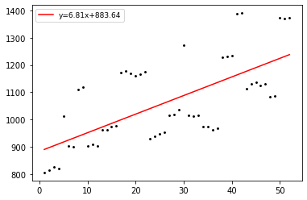

```python
# Regression
plt.plot(x, line, 'r', label='y={:.2f}x+{:.2f}'.format(slope,intercept))

plt.scatter(x, y, color = "k", s = 3.5)
plt.legend(fontsize = 9)

plt.show()
```

```python
# November of Year 5 (period 53)
print('Predicted Enrollment in November of Year 5:', round((slope * 53) + intercept))
```

```
Predicted Enrollment in November of Year 5: 1245.0
```

### d. Plot the actual enrollment against the predictions developed in (a) through (c).

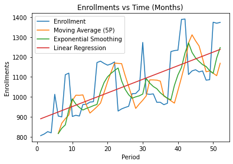

```python
q3.plot(x="Period", y=["Enrollment", "Moving Average (5P)", "Exponential Smoothing", "Linear Regression"])
plt.ylabel('Enrollments')
plt.title('Enrollments vs Time (Months)')
plt.show()
```

### e. Calculate MAD and MAPE for the predictions developed in (a) through (c).

$$E_{t} = F_{t} - D_{t}$$$$MAD = \frac{1}{n}\sum_{i=1}^{n} |E_{i}|$$$$MAPE = (\frac{1}{n}\sum_{i=1}^{n}|\frac{E_{i}}{D_{i}}|) * 100$$

```python
# Calculate Error Columns
q3['MA Error'] = q3['Moving Average (5P)'] - q3['Enrollment']
q3['Expo Error'] = q3['Exponential Smoothing'] - q3['Enrollment']
q3['Reg Error'] = q3['Linear Regression'] - q3['Enrollment']
q3
```

|  | Period | Year | Month | Enrollment | Moving Average (5P) | Exponential Smoothing | Linear Regression | MA Error | Expo Error | Reg Error |
| --- | --- | --- | --- | --- | --- | --- | --- | --- | --- | --- |
| 0 | 1 | 1 | July | 806 | None | None | 890.455733 | NaN | NaN | 84.455733 |
| 1 | 2 | 1 | August | 814 | None | None | 897.268932 | NaN | NaN | 83.268932 |
| 2 | 3 | 1 | September | 826 | None | None | 904.082131 | NaN | NaN | 78.082131 |
| 3 | 4 | 1 | October | 820 | None | None | 910.895330 | NaN | NaN | 90.895330 |
| 4 | 5 | 1 | November | 1013 | None | None | 917.708529 | NaN | NaN | -95.291471 |
| 5 | 6 | 1 | December | 904 | 816.5 | 816.5 | 924.521728 | -87.5 | -87.5 | 20.521728 |
| 6 | 7 | 2 | January | 900 | 868.25 | 842.75 | 931.334927 | -31.75 | -57.25 | 31.334927 |
| 7 | 8 | 2 | February | 1111 | 890.75 | 859.925 | 938.148126 | -220.25 | -251.075 | -172.851874 |
| 8 | 9 | 2 | March | 1119 | 909.25 | 935.247 | 944.961325 | -209.75 | -183.753 | -174.038675 |
| 9 | 10 | 2 | April | 902 | 982 | 990.373 | 951.774524 | 80 | 88.3732 | 49.774524 |
| 10 | 11 | 2 | May | 908 | 1008.5 | 963.861 | 958.587723 | 100.5 | 55.8613 | 50.587723 |
| 11 | 12 | 2 | June | 904 | 1008 | 947.103 | 965.400922 | 104 | 43.1029 | 61.400922 |
| 12 | 13 | 2 | July | 962 | 1010 | 934.172 | 972.214121 | 48 | -27.828 | 10.214121 |
| 13 | 14 | 2 | August | 963 | 958.25 | 942.52 | 979.027320 | -4.75 | -20.4796 | 16.027320 |
| 14 | 15 | 2 | September | 974 | 919 | 948.664 | 985.840519 | -55 | -25.3357 | 11.840519 |
| 15 | 16 | 2 | October | 976 | 934.25 | 956.265 | 992.653718 | -41.75 | -19.735 | 16.653718 |
| 16 | 17 | 2 | November | 1172 | 950.75 | 962.186 | 999.466917 | -221.25 | -209.814 | -172.533083 |
| 17 | 18 | 2 | December | 1179 | 968.75 | 1025.13 | 1006.280116 | -210.25 | -153.87 | -172.719884 |
| 18 | 19 | 3 | January | 1168 | 1021.25 | 1071.29 | 1013.093315 | -146.75 | -96.7091 | -154.906685 |
| 19 | 20 | 3 | February | 1159 | 1075.25 | 1100.3 | 1019.906514 | -83.75 | -58.6964 | -139.093486 |
| 20 | 21 | 3 | March | 1165 | 1123.75 | 1117.91 | 1026.719713 | -41.25 | -47.0875 | -138.280287 |
| 21 | 22 | 3 | April | 1175 | 1169.5 | 1132.04 | 1033.532912 | -5.5 | -42.9612 | -141.467088 |
| 22 | 23 | 3 | May | 929 | 1167.75 | 1144.93 | 1040.346111 | 238.75 | 215.927 | 111.346111 |
| 23 | 24 | 3 | June | 940 | 1166.75 | 1080.15 | 1047.159310 | 226.75 | 140.149 | 107.159310 |
| 24 | 25 | 3 | July | 947 | 1107 | 1038.1 | 1053.972509 | 160 | 91.1043 | 106.972509 |
| 25 | 26 | 3 | August | 953 | 1052.25 | 1010.77 | 1060.785708 | 99.25 | 57.773 | 107.785708 |
| 26 | 27 | 3 | September | 1016 | 997.75 | 993.441 | 1067.598907 | -18.25 | -22.5589 | 51.598907 |
| 27 | 28 | 3 | October | 1017 | 942.25 | 1000.21 | 1074.412106 | -74.75 | -16.7912 | 57.412106 |
| 28 | 29 | 3 | November | 1035 | 964 | 1005.25 | 1081.225305 | -71 | -29.7539 | 46.225305 |
| 29 | 30 | 3 | December | 1273 | 983.25 | 1014.17 | 1088.038504 | -289.75 | -258.828 | -184.961496 |
| 30 | 31 | 4 | January | 1015 | 1005.25 | 1091.82 | 1094.851703 | -9.75 | 76.8206 | 79.851703 |
| 31 | 32 | 4 | February | 1013 | 1085.25 | 1068.77 | 1101.664902 | 72.25 | 55.7744 | 88.664902 |
| 32 | 33 | 4 | March | 1015 | 1085 | 1052.04 | 1108.478101 | 70 | 37.0421 | 93.478101 |
| 33 | 34 | 4 | April | 973 | 1084 | 1040.93 | 1115.291300 | 111 | 67.9295 | 142.291300 |
| 34 | 35 | 4 | May | 973 | 1079 | 1020.55 | 1122.104499 | 106 | 47.5506 | 149.104499 |
| 35 | 36 | 4 | June | 961 | 1004 | 1006.29 | 1128.917698 | 43 | 45.2854 | 167.917698 |
| 36 | 37 | 4 | July | 968 | 993.5 | 992.7 | 1135.730897 | 25.5 | 24.6998 | 167.730897 |
| 37 | 38 | 4 | August | 1227 | 980.5 | 985.29 | 1142.544096 | -246.5 | -241.71 | -84.455904 |
| 38 | 39 | 4 | September | 1232 | 968.75 | 1057.8 | 1149.357295 | -263.25 | -174.197 | -82.642705 |
| 39 | 40 | 4 | October | 1234 | 1032.25 | 1110.06 | 1156.170494 | -201.75 | -123.938 | -77.829506 |
| 40 | 41 | 4 | November | 1388 | 1097 | 1147.24 | 1162.983693 | -291 | -240.757 | -225.016307 |
| 41 | 42 | 4 | December | 1390 | 1165.25 | 1219.47 | 1169.796892 | -224.75 | -170.53 | -220.203108 |
| 42 | 43 | 5 | January | 1112 | 1270.25 | 1270.63 | 1176.610091 | 158.25 | 158.629 | 64.610091 |
| 43 | 44 | 5 | February | 1130 | 1311 | 1223.04 | 1183.423290 | 181 | 93.0405 | 53.423290 |
| 44 | 45 | 5 | March | 1136 | 1281 | 1195.13 | 1190.236489 | 145 | 59.1283 | 54.236489 |
| 45 | 46 | 5 | April | 1125 | 1255 | 1177.39 | 1197.049688 | 130 | 52.3898 | 72.049688 |
| 46 | 47 | 5 | May | 1130 | 1192 | 1161.67 | 1203.862887 | 62 | 31.6729 | 73.862887 |
| 47 | 48 | 5 | June | 1084 | 1125.75 | 1152.17 | 1210.676086 | 41.75 | 68.171 | 126.676086 |
| 48 | 49 | 5 | July | 1086 | 1130.25 | 1131.72 | 1217.489285 | 44.25 | 45.7197 | 131.489285 |
| 49 | 50 | 5 | August | 1374 | 1118.75 | 1118 | 1224.302484 | -255.25 | -255.996 | -149.697516 |
| 50 | 51 | 5 | September | 1369 | 1106.25 | 1194.8 | 1231.115683 | -262.75 | -174.197 | -137.884317 |
| 51 | 52 | 5 | October | 1373 | 1168.5 | 1247.06 | 1237.928882 | -204.5 | -125.938 | -135.071118 |

#### Moving Average

```python
# MAD
print('MAD:', round(abs(q3['MA Error']).mean(), 2))

# MAPE
print('MAPE:', '{:.2%}'.format(abs(q3['MA Error'] / q3['Enrollment']).mean()))
```

```
MAD: 128.09
MAPE: 11.38%
```

#### Exponential Smoothing

```python
# MAD
print('MAD:', round(abs(q3['Expo Error']).mean(), 2))

# MAPE
print('MAPE:', '{:.2%}'.format(abs(q3['Expo Error'] / q3['Enrollment']).mean()))
```

```
MAD: 99.43
MAPE: 8.81%
```

#### Linear Regression

```python
# MAD
print('MAD:', round(q3['Reg Error'].mad(), 2))

# MAPE
print('MAPE:', '{:.2%}'.format(abs(q3['Reg Error'] / q3['Enrollment']).mean()))
```

```
MAD: 102.27
MAPE: 9.44%
```

#### Modified Data Frame with Demand, Forecast, and Error

```python
q3
```

|  | Period | Year | Month | Enrollment | Moving Average (5P) | Exponential Smoothing | Linear Regression | MA Error | Expo Error | Reg Error |
| --- | --- | --- | --- | --- | --- | --- | --- | --- | --- | --- |
| 0 | 1 | 1 | July | 806 | None | None | 890.455733 | NaN | NaN | 84.455733 |
| 1 | 2 | 1 | August | 814 | None | None | 897.268932 | NaN | NaN | 83.268932 |
| 2 | 3 | 1 | September | 826 | None | None | 904.082131 | NaN | NaN | 78.082131 |
| 3 | 4 | 1 | October | 820 | None | None | 910.895330 | NaN | NaN | 90.895330 |
| 4 | 5 | 1 | November | 1013 | None | None | 917.708529 | NaN | NaN | -95.291471 |
| 5 | 6 | 1 | December | 904 | 816.5 | 816.5 | 924.521728 | -87.5 | -87.5 | 20.521728 |
| 6 | 7 | 2 | January | 900 | 868.25 | 842.75 | 931.334927 | -31.75 | -57.25 | 31.334927 |
| 7 | 8 | 2 | February | 1111 | 890.75 | 859.925 | 938.148126 | -220.25 | -251.075 | -172.851874 |
| 8 | 9 | 2 | March | 1119 | 909.25 | 935.247 | 944.961325 | -209.75 | -183.753 | -174.038675 |
| 9 | 10 | 2 | April | 902 | 982 | 990.373 | 951.774524 | 80 | 88.3732 | 49.774524 |
| 10 | 11 | 2 | May | 908 | 1008.5 | 963.861 | 958.587723 | 100.5 | 55.8613 | 50.587723 |
| 11 | 12 | 2 | June | 904 | 1008 | 947.103 | 965.400922 | 104 | 43.1029 | 61.400922 |
| 12 | 13 | 2 | July | 962 | 1010 | 934.172 | 972.214121 | 48 | -27.828 | 10.214121 |
| 13 | 14 | 2 | August | 963 | 958.25 | 942.52 | 979.027320 | -4.75 | -20.4796 | 16.027320 |
| 14 | 15 | 2 | September | 974 | 919 | 948.664 | 985.840519 | -55 | -25.3357 | 11.840519 |
| 15 | 16 | 2 | October | 976 | 934.25 | 956.265 | 992.653718 | -41.75 | -19.735 | 16.653718 |
| 16 | 17 | 2 | November | 1172 | 950.75 | 962.186 | 999.466917 | -221.25 | -209.814 | -172.533083 |
| 17 | 18 | 2 | December | 1179 | 968.75 | 1025.13 | 1006.280116 | -210.25 | -153.87 | -172.719884 |
| 18 | 19 | 3 | January | 1168 | 1021.25 | 1071.29 | 1013.093315 | -146.75 | -96.7091 | -154.906685 |
| 19 | 20 | 3 | February | 1159 | 1075.25 | 1100.3 | 1019.906514 | -83.75 | -58.6964 | -139.093486 |
| 20 | 21 | 3 | March | 1165 | 1123.75 | 1117.91 | 1026.719713 | -41.25 | -47.0875 | -138.280287 |
| 21 | 22 | 3 | April | 1175 | 1169.5 | 1132.04 | 1033.532912 | -5.5 | -42.9612 | -141.467088 |
| 22 | 23 | 3 | May | 929 | 1167.75 | 1144.93 | 1040.346111 | 238.75 | 215.927 | 111.346111 |
| 23 | 24 | 3 | June | 940 | 1166.75 | 1080.15 | 1047.159310 | 226.75 | 140.149 | 107.159310 |
| 24 | 25 | 3 | July | 947 | 1107 | 1038.1 | 1053.972509 | 160 | 91.1043 | 106.972509 |
| 25 | 26 | 3 | August | 953 | 1052.25 | 1010.77 | 1060.785708 | 99.25 | 57.773 | 107.785708 |
| 26 | 27 | 3 | September | 1016 | 997.75 | 993.441 | 1067.598907 | -18.25 | -22.5589 | 51.598907 |
| 27 | 28 | 3 | October | 1017 | 942.25 | 1000.21 | 1074.412106 | -74.75 | -16.7912 | 57.412106 |
| 28 | 29 | 3 | November | 1035 | 964 | 1005.25 | 1081.225305 | -71 | -29.7539 | 46.225305 |
| 29 | 30 | 3 | December | 1273 | 983.25 | 1014.17 | 1088.038504 | -289.75 | -258.828 | -184.961496 |
| 30 | 31 | 4 | January | 1015 | 1005.25 | 1091.82 | 1094.851703 | -9.75 | 76.8206 | 79.851703 |
| 31 | 32 | 4 | February | 1013 | 1085.25 | 1068.77 | 1101.664902 | 72.25 | 55.7744 | 88.664902 |
| 32 | 33 | 4 | March | 1015 | 1085 | 1052.04 | 1108.478101 | 70 | 37.0421 | 93.478101 |
| 33 | 34 | 4 | April | 973 | 1084 | 1040.93 | 1115.291300 | 111 | 67.9295 | 142.291300 |
| 34 | 35 | 4 | May | 973 | 1079 | 1020.55 | 1122.104499 | 106 | 47.5506 | 149.104499 |
| 35 | 36 | 4 | June | 961 | 1004 | 1006.29 | 1128.917698 | 43 | 45.2854 | 167.917698 |
| 36 | 37 | 4 | July | 968 | 993.5 | 992.7 | 1135.730897 | 25.5 | 24.6998 | 167.730897 |
| 37 | 38 | 4 | August | 1227 | 980.5 | 985.29 | 1142.544096 | -246.5 | -241.71 | -84.455904 |
| 38 | 39 | 4 | September | 1232 | 968.75 | 1057.8 | 1149.357295 | -263.25 | -174.197 | -82.642705 |
| 39 | 40 | 4 | October | 1234 | 1032.25 | 1110.06 | 1156.170494 | -201.75 | -123.938 | -77.829506 |
| 40 | 41 | 4 | November | 1388 | 1097 | 1147.24 | 1162.983693 | -291 | -240.757 | -225.016307 |
| 41 | 42 | 4 | December | 1390 | 1165.25 | 1219.47 | 1169.796892 | -224.75 | -170.53 | -220.203108 |
| 42 | 43 | 5 | January | 1112 | 1270.25 | 1270.63 | 1176.610091 | 158.25 | 158.629 | 64.610091 |
| 43 | 44 | 5 | February | 1130 | 1311 | 1223.04 | 1183.423290 | 181 | 93.0405 | 53.423290 |
| 44 | 45 | 5 | March | 1136 | 1281 | 1195.13 | 1190.236489 | 145 | 59.1283 | 54.236489 |
| 45 | 46 | 5 | April | 1125 | 1255 | 1177.39 | 1197.049688 | 130 | 52.3898 | 72.049688 |
| 46 | 47 | 5 | May | 1130 | 1192 | 1161.67 | 1203.862887 | 62 | 31.6729 | 73.862887 |
| 47 | 48 | 5 | June | 1084 | 1125.75 | 1152.17 | 1210.676086 | 41.75 | 68.171 | 126.676086 |
| 48 | 49 | 5 | July | 1086 | 1130.25 | 1131.72 | 1217.489285 | 44.25 | 45.7197 | 131.489285 |
| 49 | 50 | 5 | August | 1374 | 1118.75 | 1118 | 1224.302484 | -255.25 | -255.996 | -149.697516 |
| 50 | 51 | 5 | September | 1369 | 1106.25 | 1194.8 | 1231.115683 | -262.75 | -174.197 | -137.884317 |
| 51 | 52 | 5 | October | 1373 | 1168.5 | 1247.06 | 1237.928882 | -204.5 | -125.938 | -135.071118 |

### f. Which prediction method would you recommend? Explain.

I would recommend predicting the enrollments using exponential smoothing because it has the lowest MAD and MAPE, which shows less deviation and percentage errors. The graph shown above indicates that the exponential smoothing line is the closest to the actual enrollment line on the graph. It follows the seasonality the most accurately of the three forecasting methods, whereas the other methods lag a bit behind when following the actual enrollment seasonality.

# Question 4: Exercise 2.27

The practice manager of a patient-centered medical home would like to develop a prediction for weekly patient appointments. Past data is shown in Table EX 2.27.

```python
q4 = pd.read_excel('IE5400_HW02_Q1-6.xlsx', sheet_name = '2.27')
```

### a. Using linear regression, predict appointments for the first four weeks in January of the following year. Plot the actual appointments against the predicted values.

```python
# variables
x = q4['Period']
y = q4['Actual']

# Regression
slope, intercept, r_value, p_value, std_err = stats.linregress(x,y)

# Print Equation
print('Regression Equation: y = ', slope, '*x + ', intercept, sep = '')
```

```
Regression Equation: y = 0.705438558402084*x + 170.4875886524823
```

```python
# First 4 weeks in January of the following year:
print('Predicted values for the first 4 weeks in January of the following year:')
for i in range(49, 53):
      print("Week ", i-48, ": ", round(slope * i + intercept), " Appointments", sep = '')
```

```
Predicted values for the first 4 weeks in January of the following year:
Week 1: 205.0 Appointments
Week 2: 206.0 Appointments
Week 3: 206.0 Appointments
Week 4: 207.0 Appointments
```

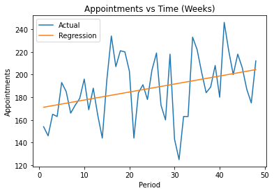

```python
q4['Regression'] = (slope * q4['Period']) + intercept
q4.plot(x = "Period", y = ["Actual", 'Regression'])
plt.ylabel('Appointments')
plt.title('Appointments vs Time (Weeks)')
plt.show()
```

### b. Using the prediction results, calculate the MAD and MAPE.

$$E_{t} = F_{t} - D_{t}$$$$MAD = \frac{1}{n}\sum_{i=1}^{n} |E_{i}|$$$$MAPE = (\frac{1}{n}\sum_{i=1}^{n}|\frac{E_{i}}{D_{i}}|) * 100$$

```python
q4['Regression'] = slope * q4['Period'] + intercept
q4['Error'] = q4['Regression'] - q4['Actual']

# MAD
print('MAD:', round(q4['Error'].mad(), 2))

# MAPE
print('MAPE:', '{:.2%}'.format(abs(q4['Error'] / q4['Actual']).mean()))
```

```
MAD: 20.67
MAPE: 11.50%
```

#### Data Frame with Demand, Forecast, and Error

```python
q4
```

|  | Period | Week | Actual | Regression | Error |
| --- | --- | --- | --- | --- | --- |
| 0 | 1 | 2017-02-01 | 154 | 171.193027 | 17.193027 |
| 1 | 2 | 2017-02-02 | 146 | 171.898466 | 25.898466 |
| 2 | 3 | 2017-02-03 | 165 | 172.603904 | 7.603904 |
| 3 | 4 | 2017-02-04 | 163 | 173.309343 | 10.309343 |
| 4 | 5 | 2017-03-01 | 193 | 174.014781 | -18.985219 |
| 5 | 6 | 2017-03-02 | 185 | 174.720220 | -10.279780 |
| 6 | 7 | 2017-03-03 | 166 | 175.425659 | 9.425659 |
| 7 | 8 | 2017-03-04 | 173 | 176.131097 | 3.131097 |
| 8 | 9 | 2017-03-05 | 179 | 176.836536 | -2.163464 |
| 9 | 10 | 2017-04-01 | 196 | 177.541974 | -18.458026 |
| 10 | 11 | 2017-04-02 | 169 | 178.247413 | 9.247413 |
| 11 | 12 | 2017-04-03 | 188 | 178.952851 | -9.047149 |
| 12 | 13 | 2017-04-04 | 164 | 179.658290 | 15.658290 |
| 13 | 14 | 2017-05-01 | 144 | 180.363728 | 36.363728 |
| 14 | 15 | 2017-05-02 | 195 | 181.069167 | -13.930833 |
| 15 | 16 | 2017-05-03 | 234 | 181.774606 | -52.225394 |
| 16 | 17 | 2017-05-04 | 207 | 182.480044 | -24.519956 |
| 17 | 18 | 2017-06-01 | 221 | 183.185483 | -37.814517 |
| 18 | 19 | 2017-06-02 | 220 | 183.890921 | -36.109079 |
| 19 | 20 | 2017-06-03 | 203 | 184.596360 | -18.403640 |
| 20 | 21 | 2017-06-04 | 144 | 185.301798 | 41.301798 |
| 21 | 22 | 2017-06-05 | 184 | 186.007237 | 2.007237 |
| 22 | 23 | 2017-07-01 | 191 | 186.712675 | -4.287325 |
| 23 | 24 | 2017-07-02 | 178 | 187.418114 | 9.418114 |
| 24 | 25 | 2017-07-03 | 204 | 188.123553 | -15.876447 |
| 25 | 26 | 2017-07-04 | 219 | 188.828991 | -30.171009 |
| 26 | 27 | 2017-08-01 | 173 | 189.534430 | 16.534430 |
| 27 | 28 | 2017-08-02 | 160 | 190.239868 | 30.239868 |
| 28 | 29 | 2017-08-03 | 218 | 190.945307 | -27.054693 |
| 29 | 30 | 2017-08-04 | 143 | 191.650745 | 48.650745 |
| 30 | 31 | 2017-08-05 | 125 | 192.356184 | 67.356184 |
| 31 | 32 | 2017-09-01 | 163 | 193.061623 | 30.061623 |
| 32 | 33 | 2017-09-02 | 163 | 193.767061 | 30.767061 |
| 33 | 34 | 2017-09-03 | 233 | 194.472500 | -38.527500 |
| 34 | 35 | 2017-09-04 | 222 | 195.177938 | -26.822062 |
| 35 | 36 | 2017-10-01 | 202 | 195.883377 | -6.116623 |
| 36 | 37 | 2017-10-02 | 184 | 196.588815 | 12.588815 |
| 37 | 38 | 2017-10-03 | 189 | 197.294254 | 8.294254 |
| 38 | 39 | 2017-10-04 | 208 | 197.999692 | -10.000308 |
| 39 | 40 | 2017-11-01 | 180 | 198.705131 | 18.705131 |
| 40 | 41 | 2017-11-02 | 246 | 199.410570 | -46.589430 |
| 41 | 42 | 2017-11-03 | 221 | 200.116008 | -20.883992 |
| 42 | 43 | 2017-11-04 | 200 | 200.821447 | 0.821447 |
| 43 | 44 | 2017-11-05 | 218 | 201.526885 | -16.473115 |
| 44 | 45 | 2017-12-01 | 206 | 202.232324 | -3.767676 |
| 45 | 46 | 2017-12-02 | 187 | 202.937762 | 15.937762 |
| 46 | 47 | 2017-12-03 | 175 | 203.643201 | 28.643201 |
| 47 | 48 | 2017-12-04 | 212 | 204.348639 | -7.651361 |

### c. Compute and graph the tracking signal for the prediction.

$Tracking$ $Signal$ = $\frac{Actual - Forecast}{MAD}, \frac{D_{t} - F_{t}}{MAD}$

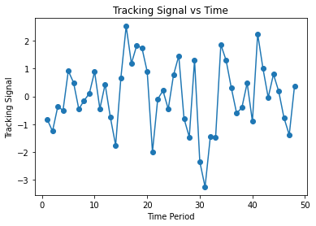

```python
# Get negative error, and MAD
MAD = q4['Error'].mad()
q4['Tracking Signal'] = -q4['Error'] / MAD

# Plot
plt.plot(q4['Period'], q4['Tracking Signal'], '-o')
plt.xlabel('Time Period')
plt.ylabel('Tracking Signal')
plt.title('Tracking Signal vs Time')
plt.show()
```

```python
# Show Values
q4
```

|  | Period | Week | Actual | Regression | Error | Tracking Signal |
| --- | --- | --- | --- | --- | --- | --- |
| 0 | 1 | 2017-02-01 | 154 | 171.193027 | 17.193027 | -0.831655 |
| 1 | 2 | 2017-02-02 | 146 | 171.898466 | 25.898466 | -1.252751 |
| 2 | 3 | 2017-02-03 | 165 | 172.603904 | 7.603904 | -0.367813 |
| 3 | 4 | 2017-02-04 | 163 | 173.309343 | 10.309343 | -0.498680 |
| 4 | 5 | 2017-03-01 | 193 | 174.014781 | -18.985219 | 0.918346 |
| 5 | 6 | 2017-03-02 | 185 | 174.720220 | -10.279780 | 0.497250 |
| 6 | 7 | 2017-03-03 | 166 | 175.425659 | 9.425659 | -0.455934 |
| 7 | 8 | 2017-03-04 | 173 | 176.131097 | 3.131097 | -0.151456 |
| 8 | 9 | 2017-03-05 | 179 | 176.836536 | -2.163464 | 0.104650 |
| 9 | 10 | 2017-04-01 | 196 | 177.541974 | -18.458026 | 0.892845 |
| 10 | 11 | 2017-04-02 | 169 | 178.247413 | 9.247413 | -0.447312 |
| 11 | 12 | 2017-04-03 | 188 | 178.952851 | -9.047149 | 0.437625 |
| 12 | 13 | 2017-04-04 | 164 | 179.658290 | 15.658290 | -0.757417 |
| 13 | 14 | 2017-05-01 | 144 | 180.363728 | 36.363728 | -1.758973 |
| 14 | 15 | 2017-05-02 | 195 | 181.069167 | -13.930833 | 0.673857 |
| 15 | 16 | 2017-05-03 | 234 | 181.774606 | -52.225394 | 2.526227 |
| 16 | 17 | 2017-05-04 | 207 | 182.480044 | -24.519956 | 1.186070 |
| 17 | 18 | 2017-06-01 | 221 | 183.185483 | -37.814517 | 1.829150 |
| 18 | 19 | 2017-06-02 | 220 | 183.890921 | -36.109079 | 1.746655 |
| 19 | 20 | 2017-06-03 | 203 | 184.596360 | -18.403640 | 0.890214 |
| 20 | 21 | 2017-06-04 | 144 | 185.301798 | 41.301798 | -1.997835 |
| 21 | 22 | 2017-06-05 | 184 | 186.007237 | 2.007237 | -0.097093 |
| 22 | 23 | 2017-07-01 | 191 | 186.712675 | -4.287325 | 0.207385 |
| 23 | 24 | 2017-07-02 | 178 | 187.418114 | 9.418114 | -0.455570 |
| 24 | 25 | 2017-07-03 | 204 | 188.123553 | -15.876447 | 0.767970 |
| 25 | 26 | 2017-07-04 | 219 | 188.828991 | -30.171009 | 1.459421 |
| 26 | 27 | 2017-08-01 | 173 | 189.534430 | 16.534430 | -0.799797 |
| 27 | 28 | 2017-08-02 | 160 | 190.239868 | 30.239868 | -1.462752 |
| 28 | 29 | 2017-08-03 | 218 | 190.945307 | -27.054693 | 1.308680 |
| 29 | 30 | 2017-08-04 | 143 | 191.650745 | 48.650745 | -2.353316 |
| 30 | 31 | 2017-08-05 | 125 | 192.356184 | 67.356184 | -3.258128 |
| 31 | 32 | 2017-09-01 | 163 | 193.061623 | 30.061623 | -1.454130 |
| 32 | 33 | 2017-09-02 | 163 | 193.767061 | 30.767061 | -1.488253 |
| 33 | 34 | 2017-09-03 | 233 | 194.472500 | -38.527500 | 1.863638 |
| 34 | 35 | 2017-09-04 | 222 | 195.177938 | -26.822062 | 1.297427 |
| 35 | 36 | 2017-10-01 | 202 | 195.883377 | -6.116623 | 0.295871 |
| 36 | 37 | 2017-10-02 | 184 | 196.588815 | 12.588815 | -0.608942 |
| 37 | 38 | 2017-10-03 | 189 | 197.294254 | 8.294254 | -0.401207 |
| 38 | 39 | 2017-10-04 | 208 | 197.999692 | -10.000308 | 0.483731 |
| 39 | 40 | 2017-11-01 | 180 | 198.705131 | 18.705131 | -0.904798 |
| 40 | 41 | 2017-11-02 | 246 | 199.410570 | -46.589430 | 2.253607 |
| 41 | 42 | 2017-11-03 | 221 | 200.116008 | -20.883992 | 1.010193 |
| 42 | 43 | 2017-11-04 | 200 | 200.821447 | 0.821447 | -0.039735 |
| 43 | 44 | 2017-11-05 | 218 | 201.526885 | -16.473115 | 0.796831 |
| 44 | 45 | 2017-12-01 | 206 | 202.232324 | -3.767676 | 0.182249 |
| 45 | 46 | 2017-12-02 | 187 | 202.937762 | 15.937762 | -0.770936 |
| 46 | 47 | 2017-12-03 | 175 | 203.643201 | 28.643201 | -1.385518 |
| 47 | 48 | 2017-12-04 | 212 | 204.348639 | -7.651361 | 0.370109 |

### d. What do you conclude about this model?

Regression is not a good for this particular model because there are clear trends, such that a constant regression line does not accurately reflect the number of appointments per time period.

# Question 5: Exercise 2.30

Under the U.S. Affordable Care Act, health care providers are encouraged to improve the coordination of care for Medicare patients through the formation of accountable care organizations (ACOs). The Centers for Medicare & Medicaid Services (CMS) defines ACOs as “groups of doctors, hospitals, and other health care providers who come together to give coordinated high-quality care to their Medicare patients.” The program not only aims to improve quality of care, but also puts incentives in place to help curb rising health care expenditures for Medicare patients. An ACO can share in the cost savings it achieves for the Medicare program.

Batten Health, a fee-for-service multispecialty group practice, is considering participation in the Medicare Shared Saving Program, Medicare’s largest ACO program. Before committing to an ACO model, the leadership team at Batten Health would like to determine whether ACOs really are more cost-effective by analyzing the performance results for year 1 of the Medicare Shared Savings Program.

### a. Navigate to https://data.cms.gov/. Select the “ACO” category and locate the “Medicare Shared Savings Program Accountable Care Organizations Performance Year 1 Results” data set. Click “Export” and download the file into MS Excel format.

```python
q5 = pd.read_csv('Performance_Year_Financial_and_Quality_Results_Archived_2013_12_31.csv')
q5.head()
```

|  | ACO Name (LBN or DBA, if applicable) | States Where Beneficiaries Reside | Agreement Start Date | Track | Participate in Advance Payment Model | Total Assigned Beneficiaries | Total Benchmark Expenditures | Total Expenditures | Total Benchmark Expenditures Minus Total Assigned Beneficiary Expenditures | Total Benchmark Expenditures Minus Total Assigned Beneficiary Expenditures as % of Total Benchmark | ... | ACO-25 | ACO-26 | ACO-27^ | ACO-28 | ACO-29 | ACO-30 | ACO-31 | CAD Comp-osite | ACO-32 | ACO-33 |
| --- | --- | --- | --- | --- | --- | --- | --- | --- | --- | --- | --- | --- | --- | --- | --- | --- | --- | --- | --- | --- | --- |
| 0 | A.M. Beajow, M.D. Internal Medicine Associates... | Nevada | 01/01/2013 | Track1 | No | 5921 | 70912015 | 67555873 | 3356142 | 4.7 | ... | 53.04 | 28.21 | 32.94 | 61.25 | 13.08 | 27.36 | NaN | 37.50 | 52.31 | 29.74 |
| 1 | AAMC Collaborative Care Network | Maryland | 01/01/2013 | Track1 | No | 10485 | 92961659 | 96240231 | -3278573 | -4.0 | ... | 87.50 | 65.35 | 17.22 | 68.61 | 74.52 | 93.33 | 88.89 | 67.31 | 90.31 | 40.66 |
| 2 | Accountable Care Clinical Services, PC | Iowa, Pennsylvania, Connecticut, Massachusetts... | 01/01/2013 | Track1 | No | 19637 | 211247324 | 200721155 | 10526169 | 5.0 | ... | 73.13 | 81.10 | 18.75 | 66.45 | 55.14 | 82.72 | 75.00 | 69.78 | 77.44 | 77.59 |
| 3 | Accountable Care Coalition of Caldwell County,... | North Carolina | 04/01/2012 | Track1 | No | 5915 | 70881173 | 71400316 | -519143 | -1.0 | ... | 13.51 | 72.54 | 35.32 | 50.61 | 32.11 | 71.32 | 75.00 | 48.17 | 54.09 | 66.31 |
| 4 | Accountable Care Coalition of Central Georgia,... | Georgia | 01/01/2013 | Track1 | No | 10589 | 106323535 | 107639420 | -1315885 | -1.0 | ... | 10.79 | 73.38 | 57.11 | 55.88 | 20.22 | 53.01 | 79.55 | 28.12 | 34.84 | 57.56 |

5 rows × 48 columns

### b. Develop a linear regression model that predicts total expenditures based on the number of assigned beneficiaries.

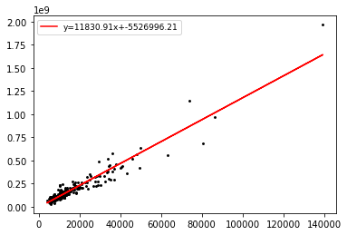

```python
# Variables
x = q5['Total Assigned Beneficiaries']
y = q5['Total Expenditures']

# Regression
slope, intercept, r_value, p_value, std_err = stats.linregress(x,y)

# Plot points with regression line
line = (slope * x) + intercept
plt.plot(x, line, 'r', label='y={:.2f}x+{:.2f}'.format(slope,intercept))

plt.scatter(x,y, color="k", s=3.5)
plt.legend(fontsize=9)

plt.show()
```

### c. Predict expenditures when the number of assigned beneficiaries is 10,000. What is the percentage change in predicted total expenditures when the number of beneficiaries increases from 10,000 to 20,000?

```python
for i in range(10000, 30000, 10000):
    print("Expenditures when the number of assigned beneficiaries is ", i, ": $", "%.2f" % round(slope * i + intercept, 2), sep = '')
```

```
Expenditures when the number of assigned beneficiaries is 10000: $112782143.19
Expenditures when the number of assigned beneficiaries is 20000: $231091282.59
```

```python
# get outputs for 10,000 and 20,000
inp = np.array([10000, 20000])
s = pd.Series(inp)
output = (slope * s) + intercept

# percentage change
print('Percentage Change from 10,000 to 20,000: ', round(s.pct_change()[1] * 100, 2), '%', sep = '')
print('Percentage Change in Predicted Total Expenditures: ', round(output.pct_change()[1] * 100, 2), "%", sep = '')
```

```
Percentage Change from 10,000 to 20,000: 100.0%
Percentage Change in Predicted Total Expenditures: 104.9%
```

### d. Predict expenditures when the number of assigned beneficiaries is 50,000. What is the percentage change in predicted total expenditures when the number of beneficiaries increases from 50,000 to 60,000?

```python
for i in range(50000, 70000, 10000):
    print("Expenditures when the number of assigned beneficiaries is ", i, ": $", "%.2f" % round(slope * i + intercept, 2), sep = '')
```

```
Expenditures when the number of assigned beneficiaries is 50000: $586018700.80
Expenditures when the number of assigned beneficiaries is 60000: $704327840.21
```

```python
# get outputs for 10,000 and 20,000
inp = np.array([50000, 60000])
s = pd.Series(inp)
output = (slope * s) + intercept

# percentage change
print('Percentage Change from 50,000 to 60,000: ', round(s.pct_change()[1] * 100, 2), '%', sep = '')
print('Percentage Change in Predicted Total Expenditures: ', round(output.pct_change()[1] * 100, 2), "%", sep = '')
```

```
Percentage Change from 50,000 to 60,000: 20.0%
Percentage Change in Predicted Total Expenditures: 20.19%
```

### e. Predict expenditures when the number of assigned beneficiaries is 100,000. What is the percentage change in predicted total expenditures when the number of beneficiaries increases from 100,000 to 110,000?

```python
for i in range(100000, 120000, 10000):
    print("Expenditures when the number of assigned beneficiaries is ", i, ": $", "%.2f" % round(slope * i + intercept, 2), sep = '')
```

```
Expenditures when the number of assigned beneficiaries is 100000: $1177564397.82
Expenditures when the number of assigned beneficiaries is 110000: $1295873537.22
```

```python
# get outputs for 100,000 and 110,000
inp = np.array([100000, 110000])
s = pd.Series(inp)
output = (slope * s) + intercept

# percentage change
print('Percentage Change from 100,000 to 110,000: ', round(s.pct_change()[1] * 100, 2), '%', sep = '')
print('Percentage Change in Predicted Total Expenditures: ', round(output.pct_change()[1] * 100, 2), "%", sep = '')
```

```
Percentage Change from 100,000 to 110,000: 10.0%
Percentage Change in Predicted Total Expenditures: 10.05%
```

### f. What is the predicted number of assigned beneficiaries when total expenditures are \$100 million? What is the predicted number of assigned beneficiaries when total expenditures are \\$500 million?

```python
inp = [100000000, 500000000]
s = pd.Series(inp)

# output
print("Predicted number of assigned beneficiaries when:")
for ele in s:
    print("Expenditure total is $", ele, ": ", round((ele - intercept) / slope), ' assigned beneficiaries', sep = '')
```

```
Predicted number of assigned beneficiaries when:
Expenditure total is $100000000: 8920.0 assigned beneficiaries
Expenditure total is $500000000: 42729.0 assigned beneficiaries
```

# Question 6

To ensure service quality in emergence department, a hospital manager likes to have a strong truth about patient arrival pattern so that he can plan sufficient resources in advance. He is looking for an accurate forecast tool for patient arrival prediction. The historical data is given in the attached Excel file. The last 10 days are used for forecast model validation.

```python
# Import dataset
q6 = pd.read_excel('IE5400_HW02_Q7.xlsx')
```

### (1) Plot ACF and PACF with lag k = 1 - 20. What do you observe from the historical patient arrivals, e.g, trend, seasonality, noise, etc?

$$acf(k)=\frac{\frac{1}{n}\sum_{i=1}^{n-k}(y_{i}-\bar{y})(y_{i+k} - \bar{y})}{\frac{1}{n}\sum_{i=1}^{n}(y_{i}-\bar{y})^2}$$$$pacf(k)=\frac{Cov(y, x_{k}|x_{1},...,x_{k+1})}{\sqrt{Var(y|x_{1},...,x_{k+1})Var(x_{k}|x_{1},...,x_{k+1})}}$$

From these graphs, I have noticed that there is a trend every 30 periods that repeats itself, granted that the appointments increase every 30 periods, but the trend and seasonality are both present in this graph. The spikes look identical in size, except that they have been shifted up in the graph over time.

#### Autocorrelation Function (ACF)

```python
# Print Autocorrelation Values
import statsmodels.api as sm
warnings.filterwarnings("ignore")
sm.tsa.acf(q6['Patient Demand'], nlags=20)
```

```
array([1.        , 0.79563382, 0.66580092, 0.6535134 , 0.63257419,
       0.57602132, 0.50880726, 0.45555604, 0.42301354, 0.34933449,
       0.23892682, 0.21121579, 0.24448574, 0.14572458, 0.09594785,
       0.09849179, 0.11945837, 0.13909392, 0.13825411, 0.16045232,
       0.19615097])
```

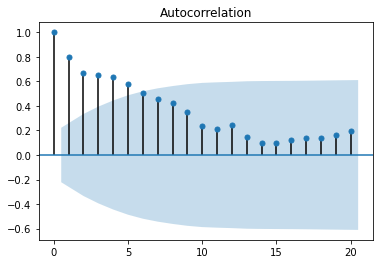

```python
# Plot Autocorrelation Function
from statsmodels.graphics import tsaplots
tsaplots.plot_acf(q6['Patient Demand'], lags=20)
plt.show()
```

#### Partial Autocorrelation Function

The partial autocorrelation plot also shows an initial decrease followed by a sudden increase in values, which indicates some level of trend and/or seasonality, which is shown in the first plot of the demand over time.

```python
# Print Partial Autocorrelation Values
sm.tsa.stattools.pacf(q6['Patient Demand'], nlags=20)
```

```
array([ 1.        ,  0.80596673,  0.09628405,  0.30055782,  0.1043581 ,
        0.01623855, -0.05152267, -0.04430886,  0.00159508, -0.14949253,
       -0.22320869,  0.05823064,  0.19408638, -0.27518315,  0.14178591,
        0.05834383,  0.17185819,  0.18228413,  0.12533888,  0.18859199,
        0.04393406])
```

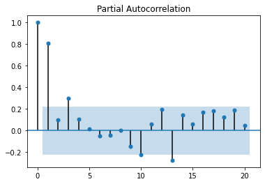

```python
# Plot Partial Autocorrelation Function
tsaplots.plot_pacf(q6['Patient Demand'], lags=20)
plt.show()
```

### (2) Develop your forecast model ARIMA (p, d, q). Elaborate your determination for the best settings.

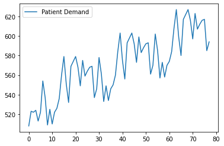

```python
q6.plot()
```

```python
# Variables
p=3
d=1
q=0

# Get model summary
from statsmodels.tsa.arima_model import ARIMA
model = ARIMA(q6['Patient Demand'], order=(p,d,q))
model_fit = model.fit()
model_fit.summary()
```

ARIMA Model Results

| Dep. Variable: | D.Patient Demand | No. Observations: | 77 |
| --- | --- | --- | --- |
| Model: | ARIMA(3, 1, 0) | Log Likelihood | -325.288 |
| Method: | css-mle | S.D. of innovations | 16.482 |
| Date: | Sat, 13 Feb 2021 | AIC | 660.575 |
| Time: | 23:42:51 | BIC | 672.294 |
| Sample: | 1 | HQIC | 665.263 |

|  | coef | std err | z | P>\|z\| | [0.025 | 0.975] |
| --- | --- | --- | --- | --- | --- | --- |
| const | 1.1274 | 0.976 | 1.156 | 0.248 | -0.785 | 3.040 |
| ar.L1.D.Patient Demand | -0.3148 | 0.113 | -2.797 | 0.005 | -0.535 | -0.094 |
| ar.L2.D.Patient Demand | -0.4623 | 0.106 | -4.364 | 0.000 | -0.670 | -0.255 |
| ar.L3.D.Patient Demand | -0.1711 | 0.113 | -1.517 | 0.129 | -0.392 | 0.050 |

Roots

|  | Real | Imaginary | Modulus | Frequency |
| --- | --- | --- | --- | --- |
| AR.1 | 0.0453 | -1.4459j | 1.4466 | -0.2450 |
| AR.2 | 0.0453 | +1.4459j | 1.4466 | 0.2450 |
| AR.3 | -2.7924 | -0.0000j | 2.7924 | -0.5000 |

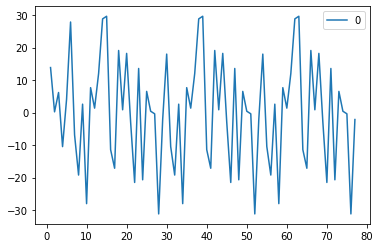

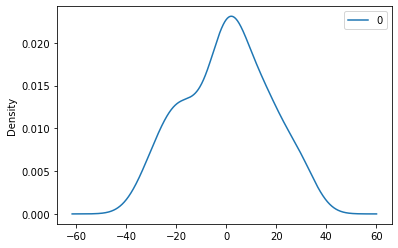

```
               0
count  77.000000
mean    0.123848
std    16.607288
min   -31.176808
25%   -11.407453
50%     0.876341
75%    12.043990
max    29.667230
```

```python
from pandas import DataFrame
# line plot of residuals
residuals = DataFrame(model_fit.resid)
residuals.plot()
plt.show()

# density plot of residuals
residuals.plot(kind='kde')
plt.show()

# summary stats of residuals
print(residuals.describe())
```

#### Evaluate ARIMA Model

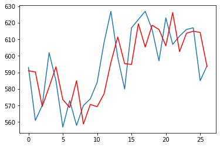

```python
# evaluate an ARIMA model using a walk-forward validation
# load dataset
X = q6.values
size = int(len(X) * 0.66)
train, test = X[0:size], X[size:len(X)]
history = [x for x in train]
predictions = list()

# walk-forward validation
for t in range(len(test)):
    model = ARIMA(history, order=(3,1,0))
    model_fit = model.fit()
    output = model_fit.forecast()
    yhat = output[0]
    predictions.append(yhat)
    obs = test[t]
    history.append(obs)

# plot forecasts against actual outcomes
plt.plot(test)
plt.plot(predictions, color='red')
plt.show()
```